# Cyclistic Bike-Share Analysis Case Study

## 3. Process

Data Cleaning - Excel: Remove negative values in column “ride_length”. Since we are measuring the duration of a bike ride, our result from ended_at - started_at should not be a negative value. A negative value may occur if a bike ride’s start or end time is recorded incorrectly. Sort “ride_length” in ASC order.

No negative data found.

Remove duplicate data in column “ride_id”. Each record in this column represents an identifier for each unique bike ride. No bike ride should have repeat values. Check ride_id for duplicates using conditional formatting Remove duplicate values from the ride_id column by selecting the “ride_id” column, using “Remove Duplicates” in the Data tab, choose “continue with the current selection,” and then click “Remove Duplicates”.

No duplicates found in datasets.

```r
#install.packages("tidyverse")  #tidyverse includes core packages like ggplot2 and readr which are helpful to wrangle data

#install.packages("lubridate")  #helps wrangle date attributes

#install.packages("ggplot2")  #helps visualize data
#install.packages("dplyr")
```

```r
library(tidyverse)  #tidyverse includes core packages like ggplot2 and readr which are helpful to wrangle data
library(lubridate)  #helps wrangle date attributes

library(ggplot2)  #helps visualize data

library(dplyr)
```

```r
#install.packages("readxl")
```

```r
library("readxl")
# xls files
data_Q1 <- read_excel("C:/Users/dorra/OneDrive/Documents/Data/Divvy_Trips_2019_Q1.xlsx")
data_Q2 <- read_excel("C:/Users/dorra/OneDrive/Documents/Data/Divvy_Trips_2019_Q2.xlsx")
data_Q3 <- read_excel("C:/Users/dorra/OneDrive/Documents/Data/Divvy_Trips_2019_Q3.xlsx")
```

Compare column names each of the files While the names don’t have to be in the same order, they DO need to match perfectly before we can use a command to join them into one file

```r
colnames(data_Q1)
```

```
##  [1] "trip_id"           "start_time"        "end_time"
##  [4] "bikeid"            "tripduration"      "from_station_id"
##  [7] "from_station_name" "to_station_id"     "to_station_name"
## [10] "usertype"          "gender"            "birthyear"
## [13] "ride_length"       "day_of_week"
```

```r
colnames(data_Q2)
```

```
##  [1] "trip_id"           "start_time"        "end_time"
##  [4] "bikeid"            "tripduration"      "from_station_id"
##  [7] "from_station_name" "to_station_id"     "to_station_name"
## [10] "usertype"          "gender"            "birthyear"
## [13] "ride_length"       "day_of_week"
```

```r
colnames(data_Q3)
```

```
##  [1] "trip_id"           "start_time"        "end_time"
##  [4] "bikeid"            "tripduration"      "from_station_id"
##  [7] "from_station_name" "to_station_id"     "to_station_name"
## [10] "usertype"          "gender"            "birthyear"
## [13] "ride_length"       "day_of_week"
```

All columns have the same name

```r
str(data_Q1)
```

```
## tibble [365,069 × 14] (S3: tbl_df/tbl/data.frame)
##  $ trip_id          : num [1:365069] 21742443 21742444 21742445 21742446 21742447 ...
##  $ start_time       : POSIXct[1:365069], format: "2019-01-01 00:04:37" "2019-01-01 00:08:13" ...
##  $ end_time         : POSIXct[1:365069], format: "2019-01-01 00:11:07" "2019-01-01 00:15:34" ...
##  $ bikeid           : num [1:365069] 2167 4386 1524 252 1170 ...
##  $ tripduration     : num [1:365069] 390 441 829 1783 364 ...
##  $ from_station_id  : num [1:365069] 199 44 15 123 173 98 98 211 150 268 ...
##  $ from_station_name: chr [1:365069] "Wabash Ave & Grand Ave" "State St & Randolph St" "Racine Ave & 18th St" "California Ave & Milwaukee Ave" ...
##  $ to_station_id    : num [1:365069] 84 624 644 176 35 49 49 142 148 141 ...
##  $ to_station_name  : chr [1:365069] "Milwaukee Ave & Grand Ave" "Dearborn St & Van Buren St (*)" "Western Ave & Fillmore St (*)" "Clark St & Elm St" ...
##  $ usertype         : chr [1:365069] "Subscriber" "Subscriber" "Subscriber" "Subscriber" ...
##  $ gender           : chr [1:365069] "Male" "Female" "Female" "Male" ...
##  $ birthyear        : num [1:365069] 1989 1990 1994 1993 1994 ...
##  $ ride_length      : POSIXct[1:365069], format: "1899-12-31 00:06:30" "1899-12-31 00:07:21" ...
##  $ day_of_week      : num [1:365069] 3 3 3 3 3 3 3 3 3 3 ...
```

```r
str(data_Q2)
```

```
## tibble [1,048,575 × 14] (S3: tbl_df/tbl/data.frame)
##  $ trip_id          : num [1:1048575] 22178529 22178530 22178531 22178532 22178533 ...
##  $ start_time       : POSIXct[1:1048575], format: "2019-04-01 00:02:22" "2019-04-01 00:03:02" ...
##  $ end_time         : POSIXct[1:1048575], format: "2019-04-01 00:09:48" "2019-04-01 00:20:30" ...
##  $ bikeid           : num [1:1048575] 6251 6226 5649 4151 3270 ...
##  $ tripduration     : num [1:1048575] 446 1048 252 357 1007 ...
##  $ from_station_id  : num [1:1048575] 81 317 283 26 202 420 503 260 211 211 ...
##  $ from_station_name: chr [1:1048575] "Daley Center Plaza" "Wood St & Taylor St" "LaSalle St & Jackson Blvd" "McClurg Ct & Illinois St" ...
##  $ to_station_id    : num [1:1048575] 56 59 174 133 129 426 500 499 211 211 ...
##  $ to_station_name  : chr [1:1048575] "Desplaines St & Kinzie St" "Wabash Ave & Roosevelt Rd" "Canal St & Madison St" "Kingsbury St & Kinzie St" ...
##  $ usertype         : chr [1:1048575] "Subscriber" "Subscriber" "Subscriber" "Subscriber" ...
##  $ gender           : chr [1:1048575] "Male" "Female" "Male" "Male" ...
##  $ birthyear        : num [1:1048575] 1975 1984 1990 1993 1992 ...
##  $ ride_length      : POSIXct[1:1048575], format: "1899-12-31 00:07:26" "1899-12-31 00:17:28" ...
##  $ day_of_week      : num [1:1048575] 2 2 2 2 2 2 2 2 2 2 ...
```

```r
str(data_Q3)
```

```
## tibble [1,048,575 × 14] (S3: tbl_df/tbl/data.frame)
##  $ trip_id          : num [1:1048575] 23479388 23479389 23479390 23479391 23479392 ...
##  $ start_time       : POSIXct[1:1048575], format: "2019-07-01 00:00:27" "2019-07-01 00:01:16" ...
##  $ end_time         : POSIXct[1:1048575], format: "2019-07-01 00:20:41" "2019-07-01 00:18:44" ...
##  $ bikeid           : num [1:1048575] 3591 5353 6180 5540 6014 ...
##  $ tripduration     : num [1:1048575] 1214 1048 1554 1503 1213 ...
##  $ from_station_id  : num [1:1048575] 117 381 313 313 168 300 168 313 43 43 ...
##  $ from_station_name: chr [1:1048575] "Wilton Ave & Belmont Ave" "Western Ave & Monroe St" "Lakeview Ave & Fullerton Pkwy" "Lakeview Ave & Fullerton Pkwy" ...
##  $ to_station_id    : num [1:1048575] 497 203 144 144 62 232 62 144 195 195 ...
##  $ to_station_name  : chr [1:1048575] "Kimball Ave & Belmont Ave" "Western Ave & 21st St" "Larrabee St & Webster Ave" "Larrabee St & Webster Ave" ...
##  $ usertype         : chr [1:1048575] "Subscriber" "Customer" "Customer" "Customer" ...
##  $ gender           : chr [1:1048575] "Male" NA NA NA ...
##  $ birthyear        : num [1:1048575] 1992 NA NA NA NA ...
##  $ ride_length      : POSIXct[1:1048575], format: "1899-12-31 00:20:14" "1899-12-31 00:17:28" ...
##  $ day_of_week      : num [1:1048575] 2 2 2 2 2 2 2 2 2 2 ...
```

Convert trip_id and bikeid to character so that they can stack correctly

```r
data_Q1 <-  mutate(data_Q1, trip_id = as.character(trip_id)
                   ,bikeid = as.character(bikeid))
data_Q2 <-  mutate(data_Q2, trip_id = as.character(trip_id)
                   ,bikeid = as.character(bikeid))
data_Q3 <-  mutate(data_Q3, trip_id = as.character(trip_id)
                   ,bikeid = as.character(bikeid))
```

Combining dataframes into one big dataframe Stack individual quarter’s data frames into one big data frame

```r
all_trips <- bind_rows(data_Q1, data_Q2, data_Q3)
```

```r
# Inspect the new table that has been created

colnames(all_trips)  #List of column names
```

```
##  [1] "trip_id"           "start_time"        "end_time"
##  [4] "bikeid"            "tripduration"      "from_station_id"
##  [7] "from_station_name" "to_station_id"     "to_station_name"
## [10] "usertype"          "gender"            "birthyear"
## [13] "ride_length"       "day_of_week"
```

```r
nrow(all_trips)  #How many rows are in data frame?
```

```
## [1] 2462219
```

```r
dim(all_trips)  #Dimensions of the data frame?
```

```
## [1] 2462219      14
```

```r
head(all_trips)  #See the first 6 rows of data frame.  Also tail(qs_raw)
```

```
## # A tibble: 6 × 14
##   trip_id  start_time          end_time            bikeid tripduration
##   <chr>    <dttm>              <dttm>              <chr>         <dbl>
## 1 21742443 2019-01-01 00:04:37 2019-01-01 00:11:07 2167            390
## 2 21742444 2019-01-01 00:08:13 2019-01-01 00:15:34 4386            441
## 3 21742445 2019-01-01 00:13:23 2019-01-01 00:27:12 1524            829
## 4 21742446 2019-01-01 00:13:45 2019-01-01 00:43:28 252            1783
## 5 21742447 2019-01-01 00:14:52 2019-01-01 00:20:56 1170            364
## 6 21742448 2019-01-01 00:15:33 2019-01-01 00:19:09 2437            216
## # ℹ 9 more variables: from_station_id <dbl>, from_station_name <chr>,
## #   to_station_id <dbl>, to_station_name <chr>, usertype <chr>, gender <chr>,
## #   birthyear <dbl>, ride_length <dttm>, day_of_week <dbl>
```

```r
str(all_trips)  #See list of columns and data types (numeric, character, etc)
```

```
## tibble [2,462,219 × 14] (S3: tbl_df/tbl/data.frame)
##  $ trip_id          : chr [1:2462219] "21742443" "21742444" "21742445" "21742446" ...
##  $ start_time       : POSIXct[1:2462219], format: "2019-01-01 00:04:37" "2019-01-01 00:08:13" ...
##  $ end_time         : POSIXct[1:2462219], format: "2019-01-01 00:11:07" "2019-01-01 00:15:34" ...
##  $ bikeid           : chr [1:2462219] "2167" "4386" "1524" "252" ...
##  $ tripduration     : num [1:2462219] 390 441 829 1783 364 ...
##  $ from_station_id  : num [1:2462219] 199 44 15 123 173 98 98 211 150 268 ...
##  $ from_station_name: chr [1:2462219] "Wabash Ave & Grand Ave" "State St & Randolph St" "Racine Ave & 18th St" "California Ave & Milwaukee Ave" ...
##  $ to_station_id    : num [1:2462219] 84 624 644 176 35 49 49 142 148 141 ...
##  $ to_station_name  : chr [1:2462219] "Milwaukee Ave & Grand Ave" "Dearborn St & Van Buren St (*)" "Western Ave & Fillmore St (*)" "Clark St & Elm St" ...
##  $ usertype         : chr [1:2462219] "Subscriber" "Subscriber" "Subscriber" "Subscriber" ...
##  $ gender           : chr [1:2462219] "Male" "Female" "Female" "Male" ...
##  $ birthyear        : num [1:2462219] 1989 1990 1994 1993 1994 ...
##  $ ride_length      : POSIXct[1:2462219], format: "1899-12-31 00:06:30" "1899-12-31 00:07:21" ...
##  $ day_of_week      : num [1:2462219] 3 3 3 3 3 3 3 3 3 3 ...
```

### Statistical summary of data.

Mainly for numeric

```r
summary(all_trips)
```

```
##    trip_id            start_time
##  Length:2462219     Min.   :2019-01-01 00:04:37.00
##  Class :character   1st Qu.:2019-04-28 12:24:23.00
##  Mode  :character   Median :2019-06-16 14:01:48.00
##                     Mean   :2019-06-06 07:32:31.89
##                     3rd Qu.:2019-07-25 16:52:09.00
##                     Max.   :2019-08-26 17:18:28.00
##
##     end_time                         bikeid           tripduration
##  Min.   :2019-01-01 00:11:07.00   Length:2462219     Min.   :      61
##  1st Qu.:2019-04-28 12:47:19.50   Class :character   1st Qu.:     424
##  Median :2019-06-16 14:28:18.00   Mode  :character   Median :     738
##  Mean   :2019-06-06 07:57:44.78                      Mean   :    1513
##  3rd Qu.:2019-07-25 17:11:18.00                      3rd Qu.:    1343
##  Max.   :2019-10-30 14:05:17.00                      Max.   :10628400
##
##  from_station_id from_station_name  to_station_id   to_station_name
##  Min.   :  1.0   Length:2462219     Min.   :  1.0   Length:2462219
##  1st Qu.: 77.0   Class :character   1st Qu.: 77.0   Class :character
##  Median :174.0   Mode  :character   Median :174.0   Mode  :character
##  Mean   :200.6                      Mean   :201.6
##  3rd Qu.:289.0                      3rd Qu.:289.0
##  Max.   :673.0                      Max.   :673.0
##
##    usertype            gender            birthyear
##  Length:2462219     Length:2462219     Min.   :1759
##  Class :character   Class :character   1st Qu.:1979
##  Mode  :character   Mode  :character   Median :1987
##                                        Mean   :1984
##                                        3rd Qu.:1992
##                                        Max.   :2014
##                                        NA's   :372398
##   ride_length                      day_of_week
##  Min.   :1899-12-31 00:01:01.00   Min.   :1.000
##  1st Qu.:1899-12-31 00:07:04.00   1st Qu.:2.000
##  Median :1899-12-31 00:12:18.00   Median :4.000
##  Mean   :1899-12-31 00:25:10.78   Mean   :4.071
##  3rd Qu.:1899-12-31 00:22:23.00   3rd Qu.:6.000
##  Max.   :1900-05-02 01:20:22.00   Max.   :7.000
##  NA's   :1
```

```r
distinct_trip_count <- all_trips %>%
  summarise(distinct_trips = n_distinct(trip_id))
distinct_trip_count
```

```
## # A tibble: 1 × 1
##   distinct_trips
##            <int>
## 1        2462219
```

There are no duplications.

```r
unique_usertypes <- unique(all_trips$usertype)

print(unique_usertypes)
```

```
## [1] "Subscriber" "Customer"
```

We only have two terms for user type which is referring to casual and member

```r
unique_day <- unique(all_trips$day_of_week)

print(unique_day)
```

```
## [1] 3 4 6 5 7 1 2
```

```r
all_trips <- all_trips %>%
  mutate(
    # Convert ride_length to actual duration in minutes
    ride_length = hour(ride_length) * 60 + minute(ride_length) + second(ride_length) / 60
  )
```

```r
negative_rides <- all_trips %>%
  mutate(duration = as.numeric(difftime(end_time, start_time, units = "secs"))) %>%
  filter(duration < 0)

# Count of negative durations
negative_count <- nrow(negative_rides)

# Print results
print(paste("Number of rides with negative duration:", negative_count))
```

```
## [1] "Number of rides with negative duration: 0"
```

There are no issues with time logs as well.

## 4.Analyze

### Descriptive analysis

```r
summary(all_trips$ride_length)
```

```
##      Min.   1st Qu.    Median      Mean   3rd Qu.      Max.      NA's
##    0.5833    7.0667   12.3000   20.0774   22.3833 1439.7500         1
```

```r
# Compare members and casual users
aggregate(all_trips$ride_length ~ all_trips$usertype, FUN = mean)
```

```
##   all_trips$usertype all_trips$ride_length
## 1           Customer              41.19733
## 2         Subscriber              13.36050
```

Casuals take the bike for a longer time then members.

```r
aggregate(all_trips$ride_length ~ all_trips$usertype, FUN = median)
```

```
##   all_trips$usertype all_trips$ride_length
## 1           Customer              26.80000
## 2         Subscriber              10.03333
```

```r
aggregate(all_trips$ride_length ~ all_trips$usertype, FUN = max)
```

```
##   all_trips$usertype all_trips$ride_length
## 1           Customer               1439.15
## 2         Subscriber               1439.75
```

```r
aggregate(all_trips$ride_length ~ all_trips$usertype, FUN = min)
```

```
##   all_trips$usertype all_trips$ride_length
## 1           Customer             0.5833333
## 2         Subscriber             1.0166667
```

```r
# Now, let's run the average ride time by each day for members vs casual users
aggregate(all_trips$ride_length ~ all_trips$usertype + all_trips$day_of_week, FUN = mean)
```

```
##    all_trips$usertype all_trips$day_of_week all_trips$ride_length
## 1            Customer                     1              42.90539
## 2          Subscriber                     1              15.11391
## 3            Customer                     2              42.68424
## 4          Subscriber                     2              12.84344
## 5            Customer                     3              40.05213
## 6          Subscriber                     3              12.92618
## 7            Customer                     4              38.90456
## 8          Subscriber                     4              13.00047
## 9            Customer                     5              39.59526
## 10         Subscriber                     5              13.05684
## 11           Customer                     6              40.04038
## 12         Subscriber                     6              12.98190
## 13           Customer                     7              42.11678
## 14         Subscriber                     7              15.09948
```

noting that 1 = Sunday and 7 = Saturday.

Casuals have longer rides on Sunday and Monday.

```r
# analyze ridership data by type and weekday
all_trips %>%
  mutate(weekday = wday(start_time, label = TRUE)) %>%  #creates weekday field using wday()
  group_by(usertype, weekday) %>%  #groups by usertype and weekday
  summarise(number_of_rides = n()                           #calculates the number of rides and average duration
            ,average_duration = mean(ride_length)) %>%      # calculates the average duration
  arrange(usertype, weekday)
```

```
## # A tibble: 14 × 4
## # Groups:   usertype [2]
##    usertype   weekday number_of_rides average_duration
##    <chr>      <ord>             <int>            <dbl>
##  1 Customer   Sun              113939             42.7
##  2 Customer   Mon               64654             40.7
##  3 Customer   Tue               60219             39.7
##  4 Customer   Wed               62799             38.9
##  5 Customer   Thu               68676             39.9
##  6 Customer   Fri               84533             40.5
##  7 Customer   Sat              139304             43.0
##  8 Subscriber Sun              163440             14.9
##  9 Subscriber Mon              287738             13.0
## 10 Subscriber Tue              313601             13.0
## 11 Subscriber Wed              322483             13.0
## 12 Subscriber Thu              308106             NA
## 13 Subscriber Fri              290346             13.0
## 14 Subscriber Sat              182381             15.1
```

### 5. Share

Let’s visualize the number of rides by rider type

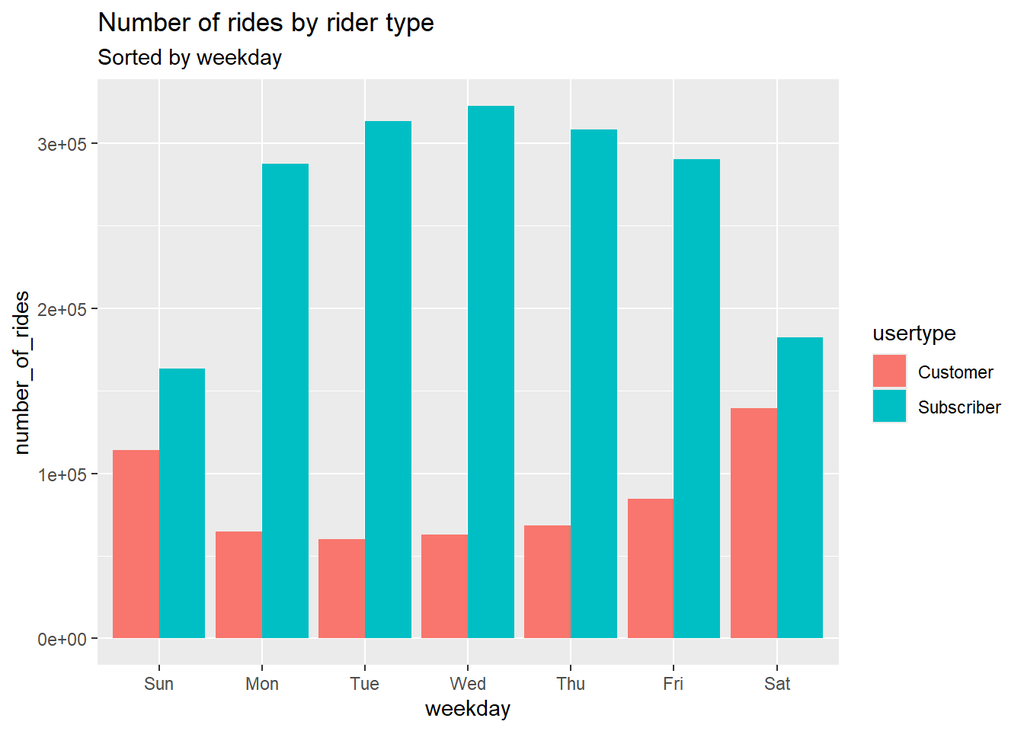

```r
# Let's visualize the number of rides by rider type
library(ggplot2)
all_trips %>%
  mutate(weekday = wday(start_time, label = TRUE)) %>%
  group_by(usertype, weekday) %>%
  summarise(number_of_rides = n()
            ,average_duration = mean(ride_length)) %>%
  arrange(usertype, weekday)  %>%
  ggplot(aes(x = weekday, y = number_of_rides, fill = usertype)) +
  geom_col(position = "dodge") +
  labs(
      title = "Number of rides by rider type",
      subtitle = "Sorted by weekday"
      )
```

```r
all_trips <- all_trips %>%
  mutate(month = month(start_time, label = TRUE))
```

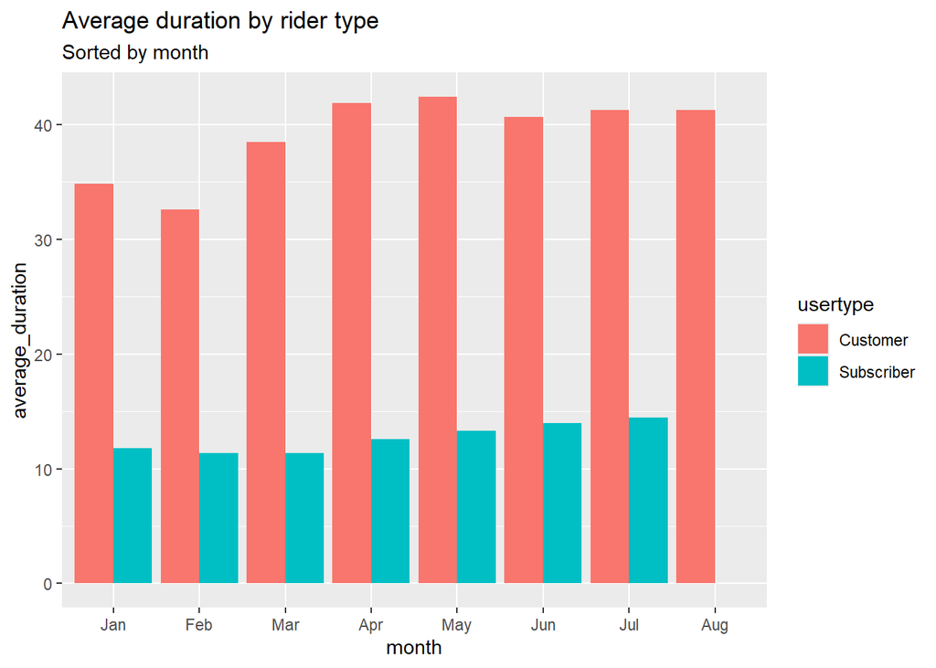

```r
# Let's create a visualization for average duration
all_trips %>%
  mutate(weekday = wday(start_time, label = TRUE)) %>%
  group_by(usertype, month) %>%
  summarise(number_of_rides = n()
            ,average_duration = mean(ride_length)) %>%
  arrange(usertype, month)  %>%
  ggplot(aes(x = month, y = average_duration, fill = usertype)) +
  geom_col(position = "dodge") +
  labs(title = "Average duration by rider type",
       subtitle = "Sorted by month")
```

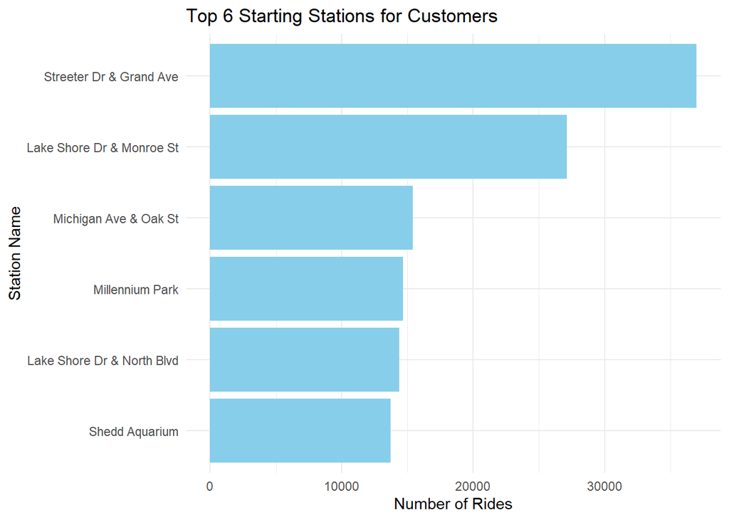

```r
# Filter and count the stations
top_stations <- all_trips %>%
  filter(usertype == "Customer") %>%
  count(from_station_name, sort = TRUE) %>%
  top_n(6, n)

# Create the histogram
ggplot(top_stations, aes(x = reorder(from_station_name, n), y = n)) +
  geom_bar(stat = "identity", fill = "skyblue") +
  coord_flip() +  # This makes it a horizontal bar chart
  labs(title = "Top 6 Starting Stations for Customers",
       x = "Station Name",
       y = "Number of Rides") +
  theme_minimal() +
  theme(axis.text.y = element_text(angle = 0, hjust = 1))
```